# Statistical inference and estimation

### The p-Value Approach to Hypothesis Testing

The p-value represents:

The probability of observing the sample data or more extreme values, given that the null hypothesis is true.

The amount of evidence against the null hypothesis, the smaller (closer to 0) the p-value, the stronger is the evidence against the null hypothesis.

If the p-value (**Green Area**) is less than or equal to the specified significance level α (**Yellow Area**) , the null hypothesis is rejected. Otherwise, we fail to reject the null hypothesis.

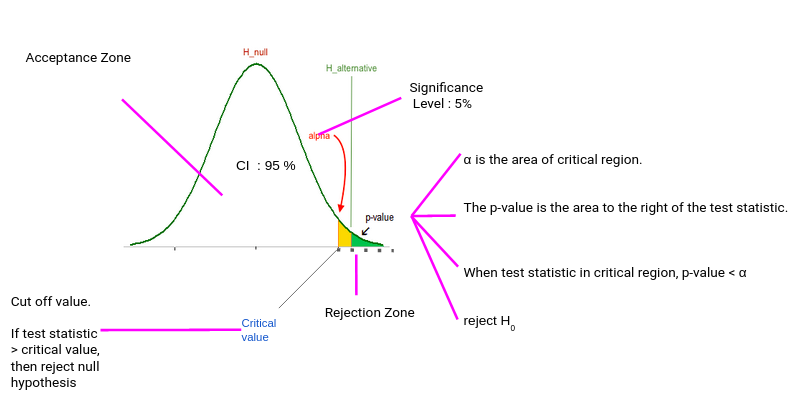

**Worked guide — critical-value and p-value approaches**

Compare critical regions and p-values in two-sided and one-sided hypothesis tests.

https://www.geo.fu-berlin.de/en/v/soga-r/Basics-of-statistics/Hypothesis-Tests/Introduction-to-Hypothesis-Testing/Critical-Value-and-the-p-Value-Approach/index.html

[figure not shown]

### Type I and Type II Errors

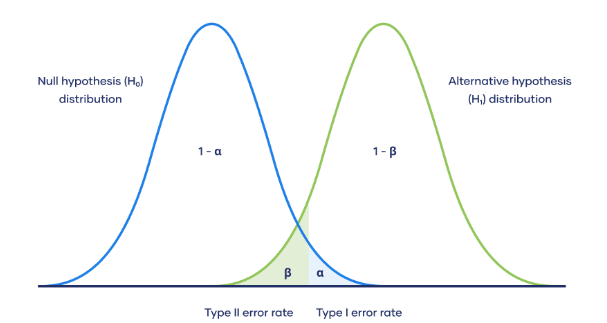

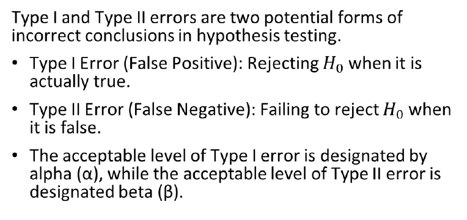

A Type I error occurs when the null hypothesis is incorrectly rejected when it is actually true.

Conversely, a Type II error happens when the null hypothesis is not rejected when it is in fact false, akin to a false negative, where we fail to detect a true effect or difference.

Consider a pharmaceutical company deciding whether a new drug is effective. A Type I error would occur if the company concludes the drug works when it does not, potentially leading to a costly recall and reputation damage when the truth emerges.

On the other hand, a Type II error would be failing to recognize the drug's efficacy, missing out on the opportunity to bring a beneficial product to market, which can result in lost revenue and competitive disadvantage. The company must balance these risks, often prioritizing the avoidance of one type of error over the other based on the potential costs and impacts associated with each.

### Hypothesis Testing Examples

### Z Test vs T Test

- A z-test is used to test a Null Hypothesis if the popula on variance is known, or if the sample size is larger than 30, for an unknown popula on variance.
- A t-test is used when the sample size is less than 30 and the popula on variance is unknown.

In our work, we will focus on T-Tests

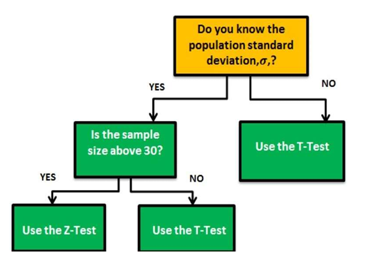

### One Sample Test – Testing for Two Tails

- **Scenario:** A logistics company believe that its average delivery time is equal to 3 days. The company wants to test this belief.
- The company collected a sample data of 40 delivery times to test if there enough evidence (at α = .05) to conclude that the population mean delivery time for the company is equal to 3 days?

H₀: μ = 3

Ha: μ ≠ 3

- Using the collected data, the t-statistic will be computed:

If the test statistic is within the rejection region, we reject the null hypothesis, otherwise we fail to reject the null hypothesis noting that the sample data did not show enough evidence against the null hypothesis.

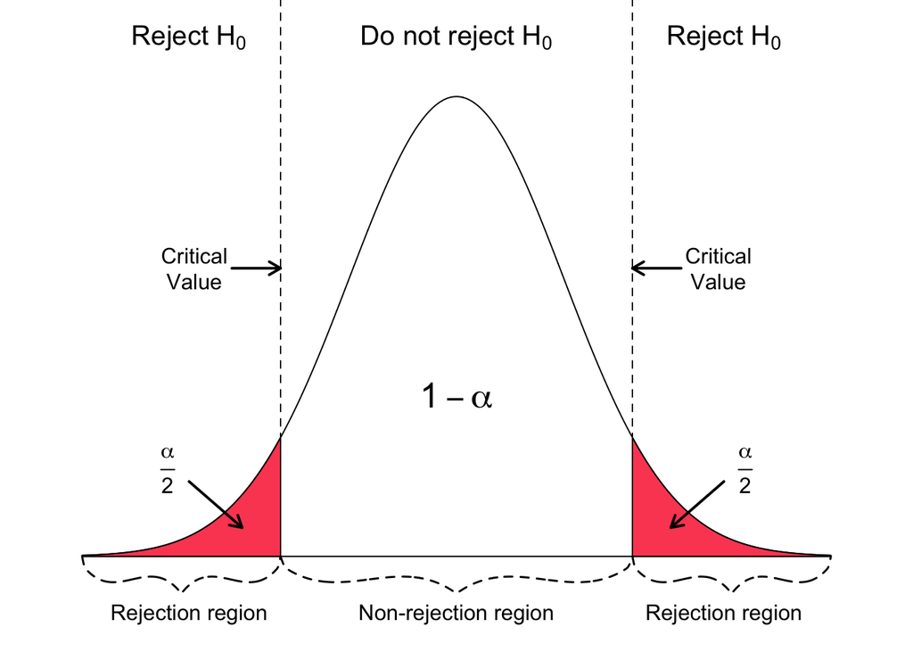

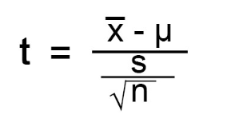

### Implement the Test Using R

| Delivery Times for 40 Days Sample – In Days |  |  |  |
| --- | --- | --- | --- |
| 1 | 4 | 1 | 4 |
| 3 | 3 | 4 | 2 |
| 5 | 1 | 6 | 3 |
| 3 | 4 | 4 | 3 |
| 3 | 2 | 4 | 4 |
| 4 | 2 | 1 | 3 |
| 2 | 3 | 3 | 3 |
| 5 | 4 | 6 | 5 |
| 3 | 5 | 2 | 4 |
| 6 | 2 | 4 | 5 |

- According to the test results, we fail to reject the null hypothesis which states that the mean delivery time is equal to 3 days.
- The collected sample data did not provide us with sufficient evidence to conclude that the mean delivery time is different from 3.
- We reached this conclusion because the t statistic falls inside the non-rejection region.
- We also reached that conclusion because the p-value (0.07315) which is greater than alpha 0.05.
- Computing t-statistic manually, t = (3.4 - 3) / (1.37 / √40) ≈ 1.84

#### Try this in R

- **Purpose:** Reproduce the two-sided mean test from the supplied summary statistics.
- **Before running:** `sqrt(variance/n)` is the estimated SE. `abs()` takes the magnitude of t. `pt(...,df=n-1,lower.tail=FALSE)` finds the upper t tail; multiplying by two gives the two-sided p-value. `c()` labels t, degrees of freedom and p.

```r
# This summary-data t test uses the source's n=40, mean 3.4 days, and variance 1.887179487 days squared.
# pt() gives tail area with df=39; doubling the upper tail of abs(t) gives the two-sided p-value.
n <- 40; t_stat <- (3.4-3)/sqrt(1.887179487/n)
c(t=t_stat, df=n-1, p_value=2*pt(abs(t_stat),df=n-1,lower.tail=FALSE))
```

```
          t          df     p_value
 1.84154944 39.00000000  0.07315585
```

**Read the result:** The p-value is about 0.0732, so at 5% we fail to reject the stated mean of three days. This does not prove equality.

### One Sample – One Tail Test – Upper Tail

**Business Context:**  
A manufacturing company believes that its daily production output is larger than 500 units.

The company collect sample outputs for 30 days.

**Hypothesis Formulation:**

Null Hypothesis (H₀): μ ≤ 500 (Baseline)

Alternative Hypothesis (H₁): μ > 500 (Output is larger)

This setup calls for a **one-tailed (upper-tailed) t-test**, as the interest lies specifically in detecting an increase in the mean output.

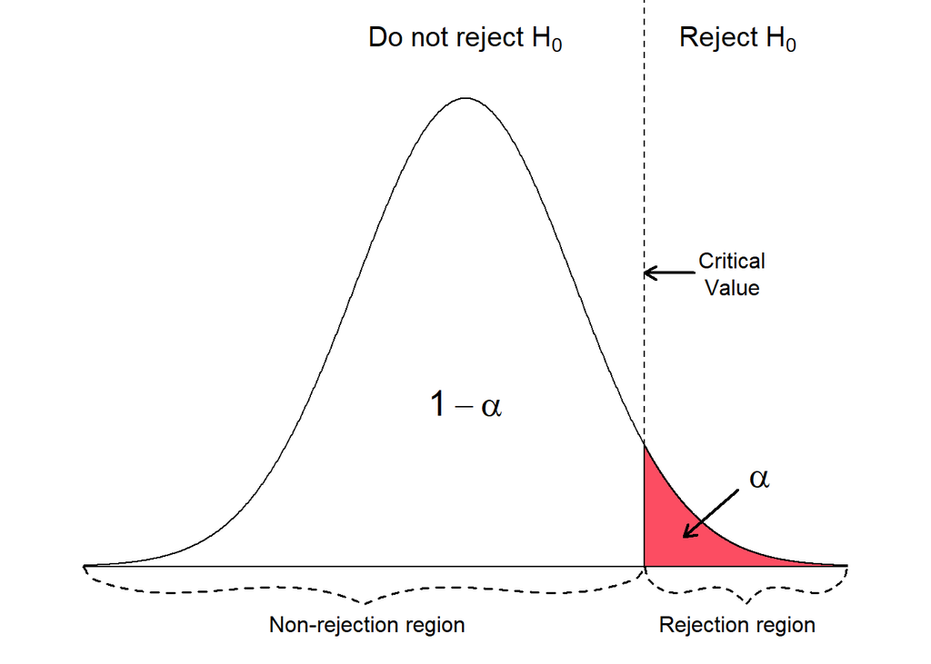

### Implement the Test Using R

| Collect Daily Output Data |  |
| --- | --- |
| 517 | 534 |
| 528 | 483 |
| 517 | 520 |
| 494 | 539 |
| 537 | 530 |
| 486 | 509 |
| 515 | 547 |
| 528 | 526 |
| 500 | 538 |
| 564 | 531 |
| 521 | 509 |
| 510 | 538 |
| 512 | 491 |
| 519 | 505 |
| 518 | 534 |

T statistic is above the critical value and P-Value is very small < alpha, therefore we reject the null hypothesis

#### Try this in R

- **Purpose:** Reproduce the upper-tail production-output test.
- **Before running:** Subtract benchmark 500 from mean output 520 and divide by `sqrt(340.0689655/30)`. `pt(t_stat,df=29,lower.tail=FALSE)` gives the upper-tail probability for the specified alternative.

```r
# Use the source summary values: n=30, mean output 520 units, and sample variance 340.0689655 units squared.
# pt(lower.tail=FALSE) tests the stated upper-tail alternative mu>500, with df=29.
t_stat <- (520-500)/sqrt(340.0689655/30)
c(t=t_stat, p_value=pt(t_stat,df=29,lower.tail=FALSE))
```

```
           t      p_value
5.940283e+00 9.382859e-07
```

**Read the result:** The p-value is about 9.38 × 10⁻⁷, supporting rejection under the stated model. The supplied summaries are used directly; no observations are fabricated.

### Two Sample T-Tests

- Two-sample t-test: Compares the means of two dependent groups (Paired t test).
- Two-sample t-test: Compares the means of two independent groups (variance assumed to be equal).
- Two-sample t-test: Compares the means of two independent groups (variance assumed to be not equal).

### Two Samples T-Test – Testing Dependent Groups (Paired T Test)

The dependent samples T-test (or paired samples t-test) is a statistical test that determines whether there is a difference between two dependent groups or samples.

We need the paired t-test whenever we survey the same group or sample at two points in time.

This can be the case, for example, in longitudinal studies with several measurement points (time series analyses) or in intervention studies with experimental designs (before-after measurement).

An example of dependent sampling is when the weight of a group of people is measured at two points in time (before and after going into a diet).

The weight of a person can be measured individually before and after going into the diet, and the difference in the measured values can be calculated in each case.

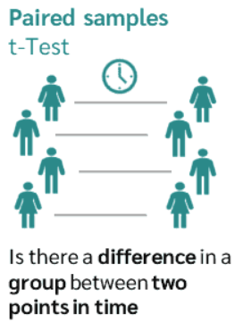

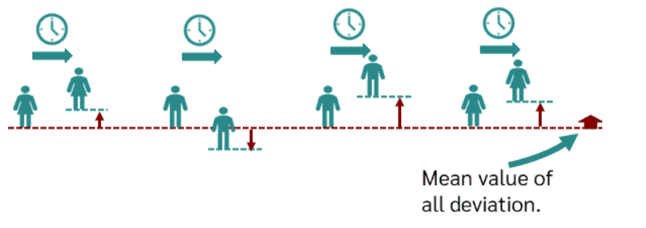

**Tutorial — paired-samples t-test (DATAtab / numiqo)**

Review paired measurements, the mean difference, assumptions and interpretation.

https://datatab.net/tutorial/paired-t-test

[figure not shown]

### Two Samples T-Test – Testing Dependent Groups (Paired T Test)

We are interested in the question whether an online statistics learning tutorial helps students improve their grades.

There are three variables of interest in the student's data set (score1, score2 and online.tutorial).

The variable online.tutorial is a binary variable, which is 1 if the student completed the online statistics learning tutorial, or 0 otherwise.

The first exam takes place before the students attended the online statistics learning tutorial.

The participation in the online statistics learning tutorial is not mandatory, however the two exams are obligatory for all students.

We want to examine if the group of students, which attended the online statistics learning tutorial, performs better on the second exam compared to the first exam.

| Random sample of students who took the online training |  |  |
| --- | --- | --- |
| ` | Score 1 | Score 2 |
| 1 | 67 | 71 |
| 2 | 62 | 64 |
| 3 | 60 | 57 |
| 4 | 53 | 52 |
| 5 | 75 | 77 |
| 6 | 64 | 79 |
| 7 | 43 | 48 |
| 8 | 74 | 70 |
| 9 | 59 | 53 |
| 10 | 54 | 58 |
| 11 | 66 | 66 |
| 12 | 81 | 90 |
| 13 | 55 | 57 |
| 14 | 64 | 68 |
| 15 | 72 | 71 |
| 16 | 76 | 78 |
| 17 | 75 | 73 |
| 18 | 90 | 92 |
| 19 | 83 | 90 |
| 20 | 64 | 73 |
| 21 | 49 | 51 |
| 22 | 41 | 51 |
| 23 | 75 | 87 |
| 24 | 66 | 66 |
| 25 | 75 | 74 |
| 26 | 49 | 57 |
| 27 | 91 | 89 |
| 28 | 68 | 69 |
| 29 | 72 | 72 |
| 30 | 87 | 93 |

|  | *Null Hypothesis states that there is no effect for the intervention* |
| --- | --- |
|  | *Alternative Hypothesis claims that the intervention caused an effect* |

**Tutorial — paired-samples t-test (DATAtab / numiqo)**

Review paired measurements, the mean difference, assumptions and interpretation.

https://datatab.net/tutorial/paired-t-test

[figure not shown]

#### Try this in R

- **Purpose:** Load the paired scores and inspect their change.
- **Before running:** `read.csv()` reads the supplied project-root CSV; `$` selects a column. `head()` previews rows; `nrow()` counts paired students. `mean(score2-score1)` averages within-student changes. Run this cell before the next test.

```r
# Load the exact 30 paired observations printed in the source slide.
paired <- read.csv("data/inferential-statistics/paired_scores.csv")
head(paired)
```

```
  observation score1 score2
1           1     67     71
2           2     62     64
3           3     60     57
4           4     53     52
5           5     75     77
6           6     64     79
```

```r
c(n=nrow(paired), mean_change=mean(paired$score2 - paired$score1))
```

```
          n mean_change
  30.000000    2.866667
```

**Read the result:** Each row is one student measured twice. The unit of the paired analysis is the within-student difference, not two independent groups.

### Two Samples T-Test – Testing Dependent Groups (Paired T Test)

- Based on the sample data and the test statistic, we found that there is a statistically significant difference between the before and after score, the after score (score2) is higher than score1.
- This finding is supported by the test statistic and the p-value, therefore we REJECT the null hypothesis, and we conclude that the online tutorial helped students in enhancing their exam performance.

**Worked example — paired-samples t-test**

Follow the analysis of paired before-and-after measurements.

https://www.geo.fu-berlin.de/en/v/soga-r/Basics-of-statistics/Hypothesis-Tests/Hypothesis-Tests-for-Two-Population-Means/Paired-Samples/index.html

[figure not shown]

#### Try this in R

- **Purpose:** Test the within-student score difference.
- **Before running:** `t.test(x,y,paired=TRUE)` analyses x minus y for each matching row. `alternative="greater"` tests a positive score2-minus-score1 mean change; `conf.level=0.95` requests the corresponding one-sided confidence bound.

```r
# Compare score2 minus score1 within the same students.
t.test(x=paired$score2, y=paired$score1, paired=TRUE,
       alternative="greater", conf.level=0.95)
```

```
    Paired t-test

data:  paired$score2 and paired$score1
t = 3.188, df = 29, p-value = 0.001711
alternative hypothesis: true mean difference is greater than 0
95 percent confidence interval:
 1.338791      Inf
sample estimates:
mean difference
       2.866667
```

**Read the result:** The test supports a positive average change under its assumptions. Pairing alone does not establish that the tutorial caused that change.

### Two Samples T-Test – Testing Independent Groups (Unpaired T Test) (variance assumed to be equal)

|  | Male Random Sample | Female Random Sample |
| --- | --- | --- |
| 1 | $39,647.68 | $29,543.60 |
| 2 | $55,726.10 | $30,972.76 |
| 3 | $34,717.77 | $33,216.12 |
| 4 | $29,999.35 | $24,143.27 |
| 5 | $50,763.66 | $40,466.69 |
| 6 | $52,433.73 | $29,543.60 |
| 7 | $44,385.84 | $47,760.48 |
| 8 | $36,599.27 | $45,054.95 |
| 9 | $47,842.44 | $42,742.79 |
| 10 | $30,854.42 | $42,202.39 |
| 11 | $58,614.72 | $40,606.41 |
| 12 | $62,887.03 | $29,783.76 |
| 13 | $48,288.53 | $46,945.17 |
| 14 | $43,191.15 | $29,555.94 |
| 15 | $43,756.58 | $45,042.30 |
| 16 | $48,453.00 | $29,555.94 |
| 17 | $23,090.67 | $45,625.09 |
| 18 | $55,660.20 | $28,017.87 |
| 19 | $57,527.17 | $35,840.90 |
| 20 | $65,776.23 | $33,648.38 |
| 21 | $50,011.69 | $46,858.67 |
| 22 | $46,213.64 | $42,463.48 |
| 23 | $42,211.41 | $33,200.27 |
| 24 | $61,384.55 | $28,338.17 |
| 25 | $49,780.18 | $26,265.35 |
| 26 | $50,474.57 | $34,373.99 |
| 27 | $43,281.92 | $37,312.85 |
| 28 | $55,484.64 | $37,709.73 |
| 29 | $24,409.73 | $35,106.01 |
| 30 | $40,489.49 | $37,807.11 |

In this section we perform a hypothesis test for the means of two populations.

The first population consist of male students and the second population of female students.

The standard deviations of the two populations are unknown but assumed to be equal.

The question is, whether there is a difference (at α 5%) in the mean annual salary of graduates related to gender (two tailed test)

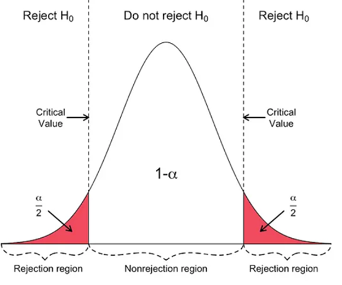

|  | *Null Hypothesis states that there is no difference* |
| --- | --- |
|  | *Alternative Hypothesis claims that there is a difference* |

**Worked example — independent means with equal variances**

Follow the pooled t-test example, with its equal-variance assumption.

https://www.geo.fu-berlin.de/en/v/soga-r/Basics-of-statistics/Hypothesis-Tests/Hypothesis-Tests-for-Two-Population-Means/Standard-Deviations-Assumed-Equal/index.html

[figure not shown]

#### Try this in R

- **Purpose:** Load the two salary samples and compare their means.
- **Before running:** `read.csv()` loads the supplied CSV. `$male` and `$female` select the two samples; `mean()` calculates their averages. Keep the source currency-label inconsistency in mind.

```r
# Load the exact printed salary samples; the source currency labels conflict.
salaries <- read.csv("data/inferential-statistics/graduate_salaries.csv")
c(male_mean=mean(salaries$male), female_mean=mean(salaries$female))
```

```
  male_mean female_mean
   46465.25    36323.47
```

**Read the result:** These are independent-group sample means. The next cell tests their difference under the specified equal-variance model.

### Two Samples T-Test – Testing Independent Groups (Unpaired T Test) (variance assumed to be equal)

- Based on the sample data and the test statistic, we found that there is a statistically significant difference between male salaries and female salaries.
- This finding is supported by the test statistic and the p-value, therefore we REJECT the null hypothesis, and we conclude that the salaries of male graduates and female graduates are not equal.

**Worked example — independent means with equal variances**

Follow the pooled t-test example, with its equal-variance assumption.

https://www.geo.fu-berlin.de/en/v/soga-r/Basics-of-statistics/Hypothesis-Tests/Hypothesis-Tests-for-Two-Population-Means/Standard-Deviations-Assumed-Equal/index.html

[figure not shown]

#### Try this in R

- **Purpose:** Run the equal-variance independent-samples test.
- **Before running:** `t.test(x,y,var.equal=TRUE)` uses a pooled variance. `alternative="two.sided"` tests for either direction; `conf.level=0.95` requests a two-sided interval for mean male minus mean female salary.

```r
# Pooled two-sided comparison under the source equal-variance assumption.
t.test(x=salaries$male, y=salaries$female, var.equal=TRUE,
       alternative="two.sided", conf.level=0.95)
```

```
    Two Sample t-test

data:  salaries$male and salaries$female
t = 4.3077, df = 58, p-value = 6.453e-05
alternative hypothesis: true difference in means is not equal to 0
95 percent confidence interval:
  5429.062 14854.493
sample estimates:
mean of x mean of y
 46465.25  36323.47
```

**Read the result:** Read the estimated difference, interval and p-value together. Equal population variances and an appropriate independent sampling model are assumptions, not consequences of a small p-value.

### Two Samples T-Test – Testing Independent Groups (Unpaired T Test) (variance assumed to be NOT equal)

In this section we perform a hypothesis test for the means of two populations.

To showcase the non-pooled t-test we test a claim that states that the annual salaries for political science female students is higher than the annual salaries of the social science female students.

The standard deviations of the two populations are unknown and assumed to be unequal.

We want to test at α 1%, whether the mean political science salary is higher than the mean salary of the social science (one tail test, upper tail).

|  | Political Science Random Sample | Social Science Random Sample |
| --- | --- | --- |
| 1 | $30,796.16 | $33,641.73 |
| 2 | $32,038.41 | $29,635.67 |
| 3 | $32,038.41 | $38,738.01 |
| 4 | $32,996.39 | $21,453.99 |
| 5 | $33,648.38 | $31,484.80 |
| 6 | $41,430.16 | $34,287.96 |
| 7 | $40,032.78 | $35,583.43 |
| 8 | $39,710.80 | $28,672.85 |
| 9 | $36,911.26 | $30,062.71 |
| 10 | $45,900.13 | $34,420.48 |
| 11 | $35,270.19 | $33,641.73 |
| 12 | $43,318.41 | $26,291.32 |
| 13 | $41,282.13 | $31,151.42 |
| 14 | $41,430.16 | $38,738.01 |
| 15 | $21,485.62 | $33,565.74 |
| 16 | $29,195.50 | $31,484.80 |
| 17 | $45,141.81 | $32,194.59 |
| 18 | $34,492.08 | $35,746.22 |
| 19 | $27,893.26 | $28,281.25 |
| 20 | $38,591.54 | $31,405.48 |
| 21 | $33,726.58 | $32,194.59 |
| 22 | $29,832.22 | $35,987.41 |
| 23 | $32,154.94 | $35,583.43 |
| 24 | $34,686.49 | $34,227.49 |
| 25 | $25,607.82 | $25,758.88 |
| 26 | $33,726.58 | $34,373.99 |
| 27 | $37,782.86 | $25,658.83 |
| 28 | $35,507.83 | $34,201.58 |
| 29 | $33,955.21 | $31,151.42 |
| 30 | $25,883.03 | $33,641.73 |

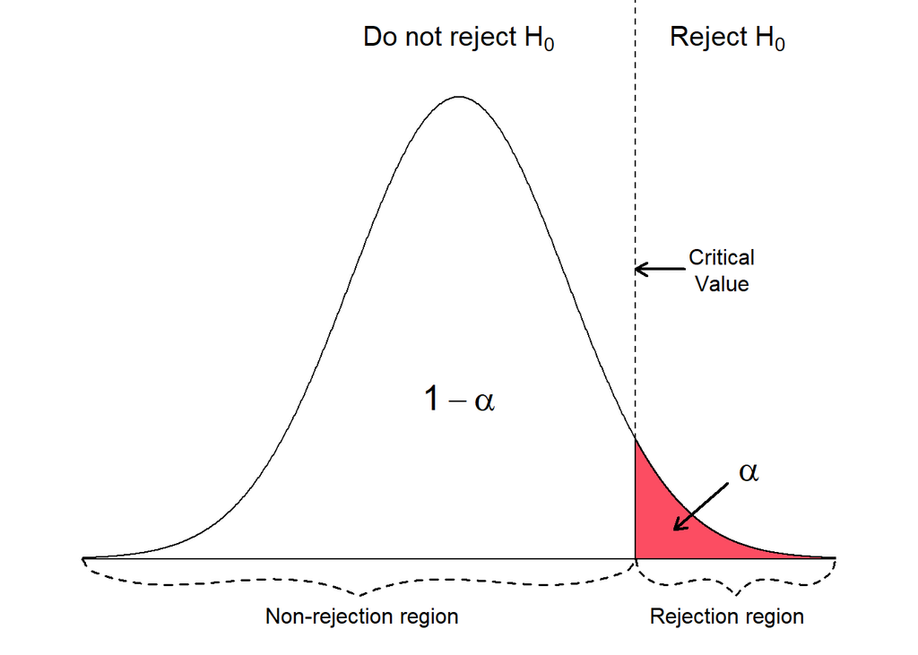

|  | *Null Hypothesis states that the salaries are equal* |
| --- | --- |
|  | *Alternative Hypothesis claims that political science is higher* |

**Worked example — independent means with unequal variances**

Follow the unequal-variance t-test example.

https://www.geo.fu-berlin.de/en/v/soga-r/Basics-of-statistics/Hypothesis-Tests/Hypothesis-Tests-for-Two-Population-Means/Standard-Deviations-Not-Assumed-Equal/index.html

[figure not shown]

#### Try this in R

- **Purpose:** Load the two female-graduate salary samples.
- **Before running:** `read.csv()` imports the CSV; `$` selects each subject’s salary column. `mean()` summarises each sample. Run this before the comparison on the following slide.

```r
# Load the exact printed female-graduate salary samples.
majors <- read.csv("data/inferential-statistics/female_major_salaries.csv")
c(political_science_mean=mean(majors$political_science),
  social_science_mean=mean(majors$social_science))
```

```
political_science_mean    social_science_mean
              34882.24               32108.72
```

**Read the result:** The two displayed means describe these samples. Preserve the source units and avoid interpreting a sample difference as causal.

### Two Samples T-Test – Testing Independent Groups (Unpaired T Test) (variance assumed to be NOT equal)

- Based on the sample data and the test statistic, we found that there is no statistically significant difference (at α 1%) between the salaries of political science and social science.
- This finding is supported by the test statistic and the p-value, therefore we FAIL TO REJECT the null hypothesis which states that the salaries of political science and social science are equal for female graduates.

**Worked example — independent means with unequal variances**

Follow the unequal-variance t-test example.

https://www.geo.fu-berlin.de/en/v/soga-r/Basics-of-statistics/Hypothesis-Tests/Hypothesis-Tests-for-Two-Population-Means/Standard-Deviations-Not-Assumed-Equal/index.html

[figure not shown]

#### Try this in R

- **Purpose:** Use Welch’s test for the stated directional comparison.
- **Before running:** `var.equal=FALSE` avoids assuming equal population variances. `alternative="greater"` tests Political Science minus Social Science above zero. `conf.level=0.99` matches the source 1% one-sided question.

```r
# Welch comparison for the stated one-sided question at alpha 0.01.
t.test(x=majors$political_science, y=majors$social_science,
       alternative="greater", var.equal=FALSE, conf.level=0.99)
```

```
    Welch Two Sample t-test

data:  majors$political_science and majors$social_science
t = 2.1512, df = 50.421, p-value = 0.01814
alternative hypothesis: true difference in means is greater than 0
99 percent confidence interval:
 -324.1923       Inf
sample estimates:
mean of x mean of y
 34882.24  32108.72
```

**Read the result:** The one-sided p-value is about 0.0182, above 0.01; fail to reject at the stated level. Do not change direction or significance level after examining the result.

### Introduction to Proportion Tests

- **A Proportion** is a fraction or percentage of a population exhibiting a specific trait (e.g., success/failure).
- Proportion tests allow us to **infer population parameters** from sample data.

**Key Differences from t-tests:**

- Applied to **categorical data** (e.g., success/failure), not continuous variables.
- Uses the **normal approximation** to the binomial distribution. The **central limit theorem** says: if the sample size is large enough, the binomial distribution starts to look like a **normal distribution**.
- Therefore, to use the normal distribution as an approximation for the binomial, both of these must be true:

𝑛.𝑝 ≥ 10

𝑛.(1−𝑝) ≥ 10

Where:

𝑛 = sample size

𝑝 = hypothesized population proportion (under the null hypothesis)

### One-Sample Proportion Test

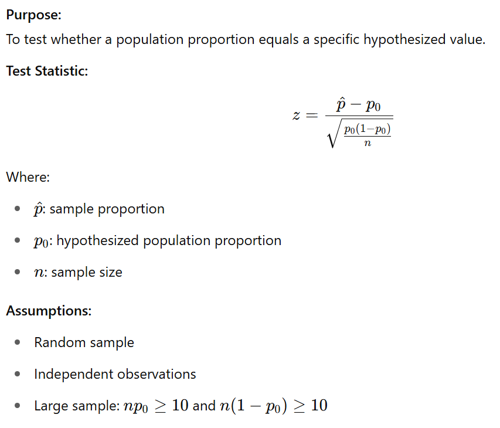

### Example

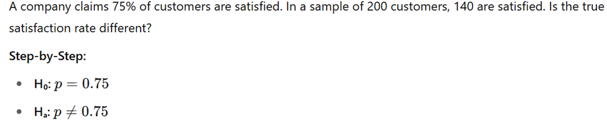

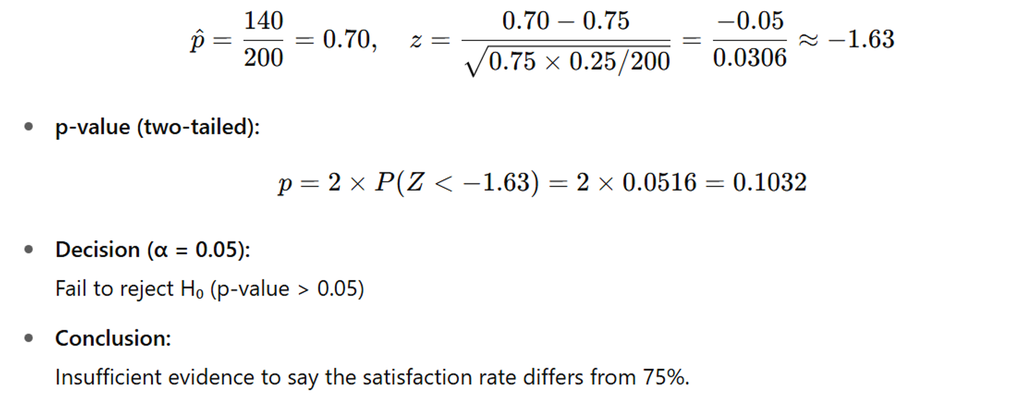

#### Try this in R

- **Purpose:** Test the stated population satisfaction rate.
- **Before running:** `prop.test(x=140,n=200,p=0.75)` uses 140 successes among 200 observations against null rate 0.75. `alternative="two.sided"` allows either direction; `correct=FALSE` omits continuity correction to match the uncorrected score calculation.

```r
# prop.test() tests the source's 140 satisfied customers out of 200 against p=0.75.
# correct=FALSE omits continuity correction to match the source normal-approximation calculation.
prop.test(140,200,p=0.75,alternative="two.sided",correct=FALSE)
```

```
    1-sample proportions test without continuity correction

data:  140 out of 200, null probability 0.75
X-squared = 2.6667, df = 1, p-value = 0.1025
alternative hypothesis: true p is not equal to 0.75
95 percent confidence interval:
 0.6332093 0.7592526
sample estimates:
  p
0.7
```

**Read the result:** The sample rate is 70%. Compare p with the chosen significance level, under an appropriate independent sampling model; the result does not establish the null as true.

### Two-Samples Proportion Test

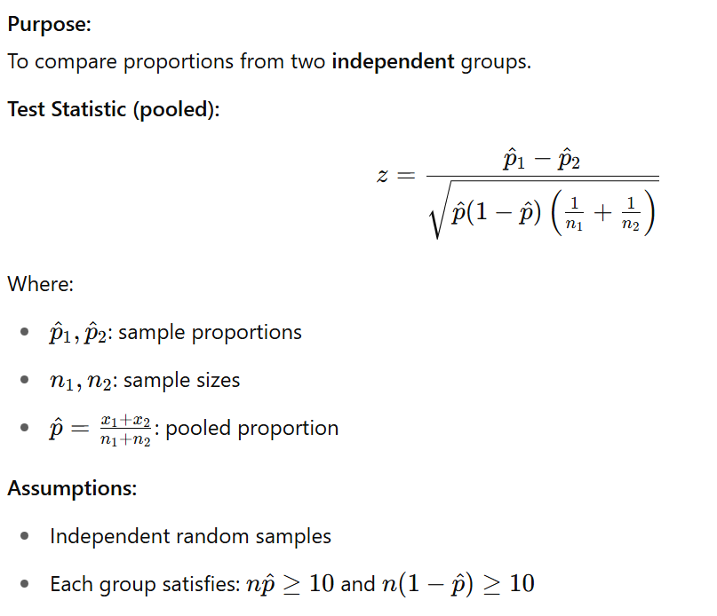

### Example: Does the New Treatment Work?

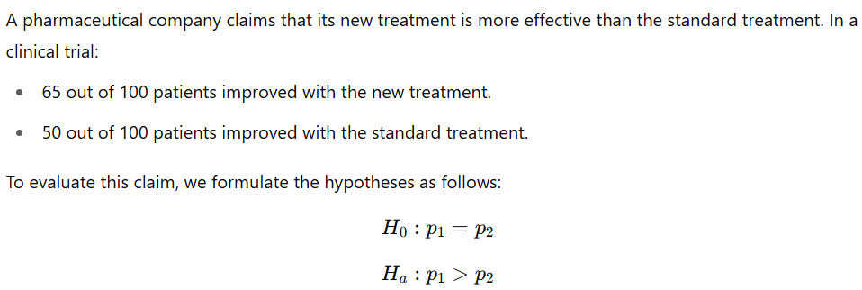

This is a one-tailed test for comparing two proportions

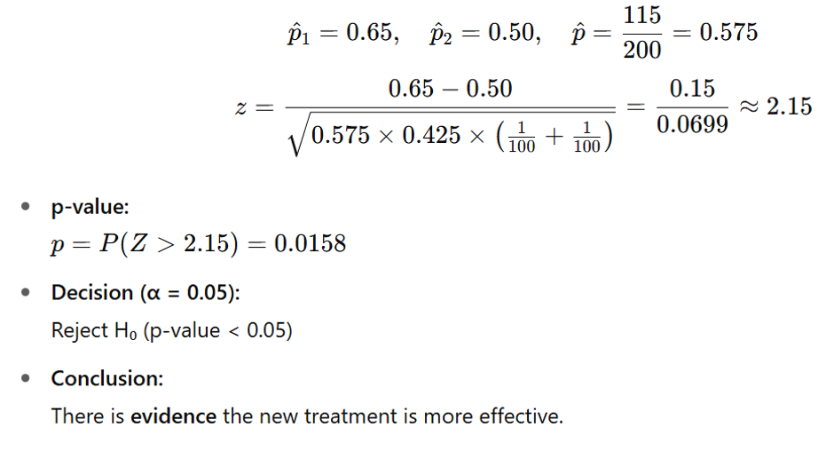

#### Try this in R

- **Purpose:** Compare the treatment success counts.
- **Before running:** The first `c()` supplies success counts and the second their group totals, in matching order. `alternative="greater"` tests the first rate above the second; `correct=FALSE` omits continuity correction.

```r
# prop.test() compares 65/100 in the new-treatment group with 50/100 in the standard-treatment group.
# greater sets the source's one-sided alternative; correct=FALSE matches its uncorrected pooled z test.
prop.test(c(65,50),c(100,100),alternative="greater",correct=FALSE)
```

```
    2-sample test for equality of proportions without continuity correction

data:  c(65, 50) out of c(100, 100)
X-squared = 4.6036, df = 1, p-value = 0.01595
alternative hypothesis: greater
95 percent confidence interval:
 0.03633835 1.00000000
sample estimates:
prop 1 prop 2
  0.65   0.50
```

**Read the result:** The observed rates are 65% and 50%, a 15-percentage-point difference. Interpret the one-sided test under the study’s design and assumptions.

### Hypothesis Testing for Categorical Data

Chi-Square Tests

### Introduction to Chi-Square Tests

Definition: Chi-square tests are statistical methods used to determine whether there's a significant association between categorical variables or whether observed data differs significantly from expected values.

Types of Chi-Square Tests:

Test of Independence: Determines if two or more categories are independent.

Goodness of Fit Test: Determines if a sample matches an expected distribution.

### Examples

**Test of Independence**

- **Marketing**: Is customer gender associated with product preference?
- **HR Analytics**: Is employee department linked to job satisfaction level?
- **Retail**: Does store location affect the type of payment method used?
- **Healthcare Management**: Is patient age group related to preferred appointment times?
- **Customer Service**: Is complaint category associated with region?

### Chi-Square Steps – Test of Independence

Step-by-Step Process:

1. Set a contingency table to show the expected frequencies and the observed frequencies.

2. Calculate the expected frequencies for each cell using the following formula.

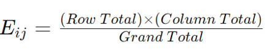

3. Compute Chi-Square statistic using the formula

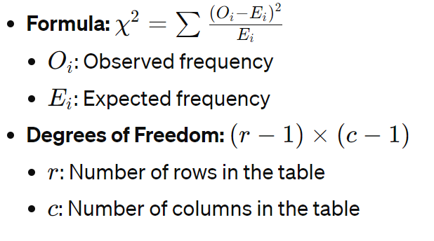

### Chi-Square Steps – Test of Independence

4. Use the Chi-Square distribution to find the Chi-Square statistic and compare it to the critical values at common significance level e.g. (0.05)

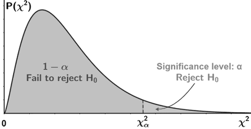

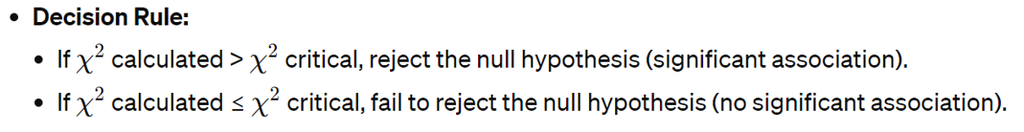

### Example: Product Preference Across Age Groups

A company wants to determine if there is a significant association between the age group of its customers and their preference for one of two new beverage products.

The marketing team has conducted a survey and **collected data** from different age groups.

The table below shows the **observed frequency** table based on the survey:

|  | **Product A** | **Product B** | **Total** |
| --- | --- | --- | --- |
| **Under 30** | 30 | 40 | 70 |
| **30 to 50** | 50 | 30 | 80 |
| **Over 50** | 20 | 30 | 50 |
| **Total** | 100 | 100 | 200 |

**Task:** Perform a Chi-Square Test of Independence to determine if there's a significant relationship between age group and product preference.

#### Try this in R

- **Purpose:** Enter the product-preference counts.
- **Before running:** `matrix()` arranges the values into `nrow=3` rows. `byrow=TRUE` fills each age-group row in order. `dimnames=list(...)` names the rows and columns; `c()` makes each label vector. Counts, rather than percentages, are entered.

```r
# Enter the original observed counts, with age groups as rows.
beverages <- matrix(c(30,40,50,30,20,30), nrow=3, byrow=TRUE,
  dimnames=list(c("Under 30","30 to 50","Over 50"),
                c("Product A","Product B")))
beverages
```

```
         Product A Product B
Under 30        30        40
30 to 50        50        30
Over 50         20        30
```

**Read the result:** The table contains 200 observations. This cell defines beverages for the following expected-count and test calculations.

### State the Null and the Alternative Hypothesis

For a **Chi-Square Test of Independence**, the hypotheses are defined in terms of whether the two categorical variables are related.

**Null Hypothesis (H₀):** There is **no association** between customer age group and beverage product preference.  
Equivalently, product preference is **independent** of age group.

**Alternative Hypothesis (H₁):** There **is an association** between customer age group and beverage product preference.  
Equivalently, product preference is **not independent** of age group.

These hypotheses set up the test to evaluate whether the observed differences in product preference across age groups are due to random variation or reflect a statistically significant relationship.

### Calculate Expected Counts in R

#### Try this in R

- **Purpose:** Calculate the expected counts under independence.
- **Before running:** `rowSums()` and `colSums()` give group totals. `outer(...,FUN="*")` multiplies every row total by every column total. Divide by `sum(beverages)`, the grand total, to obtain the expected table.

```r
# Expected counts under independence: row total times column total / grand total.
expected <- outer(X=rowSums(beverages), Y=colSums(beverages), FUN="*") /
            sum(beverages)
expected
```

```
         Product A Product B
Under 30        35        35
30 to 50        40        40
Over 50         25        25
```

**Read the result:** Expected counts describe the independence model, not newly observed people. Compare them with the observed table before testing.

### Calculate Chi-Square Value

| **Category (Age Group, Product)** | **Observed (O)** | **Expected (E)** | **O−E** | **(O−E)^2** | **E(O−E)^2** |
| --- | --- | --- | --- | --- | --- |
| Under 30, Product A | 30 | 35 | -5 | 25 | 25/35≈0.714 |
| Under 30, Product B | 40 | 35 | 5 | 25 | 25/35≈0.714 |
| 30 to 50, Product A | 50 | 40 | 10 | 100 | 100/40=2.500 |
| 30 to 50, Product B | 30 | 40 | -10 | 100 | 100/40=2.500 |
| Over 50, Product A | 20 | 25 | -5 | 25 | 25/25=1.000 |
| Over 50, Product B | 30 | 25 | 5 | 25 | 25/25=1.000 |
| Total | 200 | 200 |  |  | χ2≈8.428 |

### Calculate the Chi-Square Test in R

**Interpretation**

After calculating the Chi-Square statistic and comparing it with the critical value from a Chi-Square distribution table (or using p-value), you can conclude whether there is a statistically significant association between age group and product preference.

#### Try this in R

- **Purpose:** Calculate the chi-square statistic and its p-value.
- **Before running:** `chisq.test(x=beverages)` tests independence in the count table. `correct=FALSE` disables the optional 2×2 continuity correction; this 3×2 table does not use it. `<-` stores the result as chi.

```r
# Compare the observed and expected counts with the chi-square test.
chi <- chisq.test(x=beverages, correct=FALSE)
chi
```

```
    Pearson's Chi-squared test

data:  beverages
X-squared = 8.4286, df = 2, p-value = 0.01478
```

**Read the result:** The statistic is about 8.4286 on two degrees of freedom, with p≈0.0148. Under the sampling model this is evidence of association, not causation.

### Review the Calculation in R

#### Try this in R

- **Purpose:** Review the cell contributions to the test statistic.
- **Before running:** `(observed-expected)^2/expected` calculates each contribution. `sum()` adds them. `$parameter` selects the degrees of freedom and `$p.value` the p-value; `unname()` removes the parameter’s label inside the named output vector.

```r
# Review each contribution before adding the chi-square statistic.
contributions <- (beverages - expected)^2 / expected
contributions
```

```
         Product A Product B
Under 30 0.7142857 0.7142857
30 to 50 2.5000000 2.5000000
Over 50  1.0000000 1.0000000
```

```r
c(chi_square=sum(contributions), df=unname(chi$parameter),
  p_value=chi$p.value)
```

```
chi_square         df    p_value
8.42857143 2.00000000 0.01478288
```

**Read the result:** The contributions sum to the same chi-square statistic. Small rounding differences from the hand table are expected.

### Hypothesis Testing for More than Two Populations Means

One Way ANOVA

### Introduction to One-Way ANOVA

**Definition:** One-Way ANOVA is a statistical test that compares the means of three or more independent groups to determine if at least one group mean is statistically different from the others.

**Purpose:** To test for significant differences between the means of multiple groups when you have one categorical independent variable and one continuous dependent variable.

Appropriate Use Cases:

Comparing customer satisfaction levels across different store locations.

Examining student performance across different teaching methods.

Key Advantage:

Allows simultaneous comparison of more than two groups, providing a broader analysis than t-tests.

### One Way ANOVA

Hypothesis in One-Way ANOVA:

Null Hypothesis (H0): All group means are equal.

Alternative Hypothesis (H1): At least one group mean is different from the others.

How to Calculate?

- Calculate Group Means and Overall Mean
- Compute Sum of Squares:

Total Sum of Squares (SST): Variability of all data points around the overall mean.

Within-Group Sum of Squares (SSW): Variability within each group.

Between-Group Sum of Squares (SSB): Variability due to the interaction between the groups.

- Calculate Mean Squares:

Mean Square Between (MSB): SSB divided by the degrees of freedom between groups (k-1).

Mean Square Within (MSW): SSW divided by the degrees of freedom within groups (N-k).

- F-Statistic:

F = MSB / MSW

### ANOVA Example

Scenario: A school tests three different teaching methods to determine which one results in the best performance on a standardized test.

The students are randomly assigned to one of three groups, each receiving instruction through a different method.

Their scores on a standardized test are recorded.

Variables:

Group: The teaching method group (A, B, C)

Score: The score each student received on the standardized test.

| **Student ID** | **Group** | **Score** |
| --- | --- | --- |
| 1 | A | 82 |
| 2 | A | 88 |
| 3 | A | 84 |
| 4 | A | 90 |
| 5 | A | 85 |
| 6 | B | 78 |
| 7 | B | 75 |
| 8 | B | 80 |
| 9 | B | 82 |
| 10 | B | 77 |
| 11 | C | 90 |
| 12 | C | 92 |
| 13 | C | 95 |
| 14 | C | 91 |
| 15 | C | 94 |

#### Try this in R

- **Purpose:** Fit the one-way ANOVA for the teaching-method scores.
- **Before running:** `read.csv()` loads the 15 supplied scores. In `aov(score~group,data=methods)`, `~` means model score by group; `data` names the table. `summary()` displays the ANOVA F test.

```r
# read.csv() loads the exact 15 scores printed for the three teaching methods.
# aov(score~group) fits one-way ANOVA; summary() reports its F test under independent normal errors and equal variances.
# Open the course folder in Positron; paths start in that folder.
methods <- read.csv("data/inferential-statistics/teaching_methods.csv")
summary(aov(score~group,data=methods))
```

```
            Df Sum Sq Mean Sq F value   Pr(>F)
group        2  490.5  245.27   33.75 1.18e-05 ***
Residuals   12   87.2    7.27
---
Signif. codes:  0 '***' 0.001 '**' 0.01 '*' 0.05 '.' 0.1 ' ' 1
```

**Read the result:** The omnibus test asks whether all population group means are equal. A rejection does not establish that every pair differs or identify one uniquely best method.

### Interpreting Results

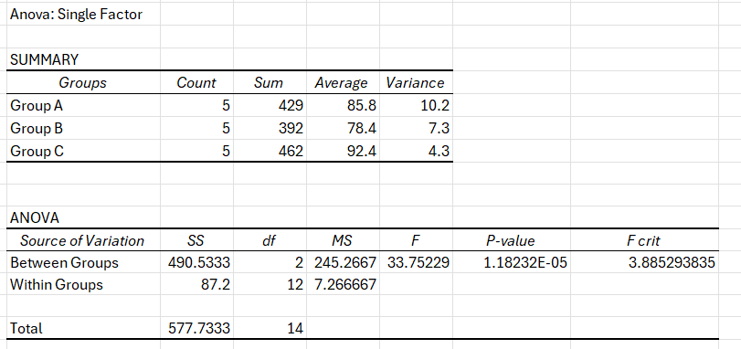

F-Statistic and P-Value:

An F-Statistic higher than the critical value or a P-value less than the alpha level (e.g., 0.05) indicates significant differences between group means.

In our example, both the F-Statistic and the P-value indicate significant difference between groups means, therefore we reject the null hypothesis.

Post Hoc Tests: If the ANOVA is significant, perform post hoc tests (e.g., Tukey’s HSD) to determine which specific groups differ from each other.

### 2-Way ANOVA

**Case Study: Effect of Teaching Method and Gender on Student Performance**

**Objective:**

A school administrator wants to investigate whether **student performance** is affected by:

- **Teaching method** (Traditional vs. Online)
  - **Student gender** (Male vs. Female)

This leads to a **2x2 factorial design**:

- Factor A: Teaching Method (Traditional, Online)
- Factor B: Gender (Male, Female)
- Response Variable: Final Exam Score (numerical)

### 2-Way ANOVA

| **Gender** | **Teaching Method** | **Exam Score** |
| --- | --- | --- |
| Male | Traditional | 75 |
| Male | Traditional | 78 |
| Female | Traditional | 85 |
| Female | Traditional | 82 |
| Male | Online | 70 |
| Male | Online | 68 |
| Female | Online | 80 |
| Female | Online | 83 |

|  | Traditional |  | Online |  |
| --- | --- | --- | --- | --- |
|  | Male | Female | Male | Female |
| Score1 | 75 | 85 | 70 | 80 |
| Score2 | 78 | 82 | 68 | 83 |

#### Try this in R

- **Purpose:** Fit both factors and their interaction for the eight observations.
- **Before running:** `factor()` treats the source gender/method values as categories. In the formula, `gender*method` includes both main effects and their interaction. `aov()` fits the model; `summary()` displays its tests.

```r
# factor() treats gender and method as categories in the exact eight printed observations.
# gender*method includes both main effects and their interaction; aov() assumes independent, equal-variance normal errors.
# Open the course folder in Positron; paths start in that folder.
teaching <- read.csv("data/inferential-statistics/teaching_gender.csv")
teaching$gender <- factor(teaching$gender)
teaching$method <- factor(teaching$method)
summary(aov(score~gender*method,data=teaching))
```

```
              Df Sum Sq Mean Sq F value  Pr(>F)
gender         1 190.12  190.12  49.065 0.00219 **
method         1  45.13   45.13  11.645 0.02697 *
gender:method  1  15.13   15.13   3.903 0.11939
Residuals      4  15.50    3.87
---
Signif. codes:  0 '***' 0.001 '**' 0.01 '*' 0.05 '.' 0.1 ' ' 1
```

**Read the result:** Read the main-effect and interaction rows separately, conditional on independent, common-variance normal errors. Eight observations give limited information for checking these assumptions.

### How to Select Test Type

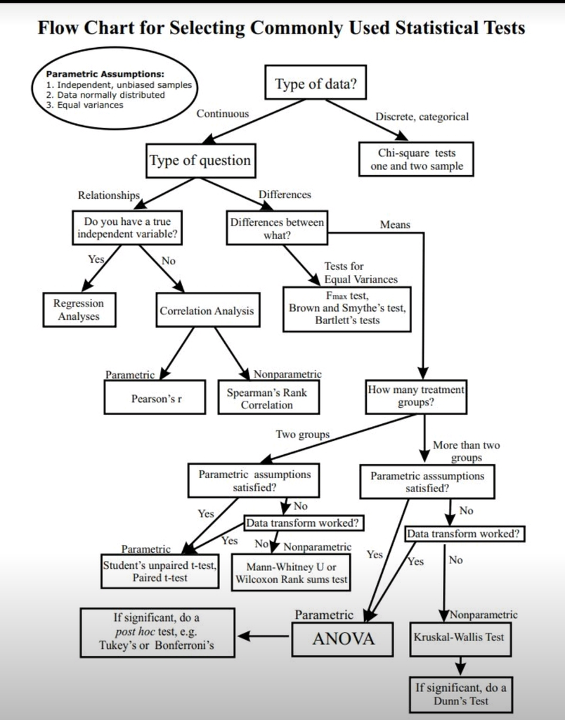

## 4.3 Regression

### Introduction to Regression Analysis

Definition: Regression analysis is a powerful statistical method used for predicting a dependent variable based on one or more independent variables.

Purpose: To understand how the typical value of the dependent variable changes when any one of the independent variables is varied, while the other independent variables are held fixed

### Types of Regression

Simple Linear Regression: Involves one independent variable and one dependent variable and the relationship between them is modeled by a linear function.

Multiple Linear Regression (Focus of this presentation): Involves multiple independent variables influencing a single dependent variable.

Other Types: Logistic regression, polynomial regression, Ridge Regression, Lasso Regression etc., used for more specific types of data and relationships.

### The Regression Equation

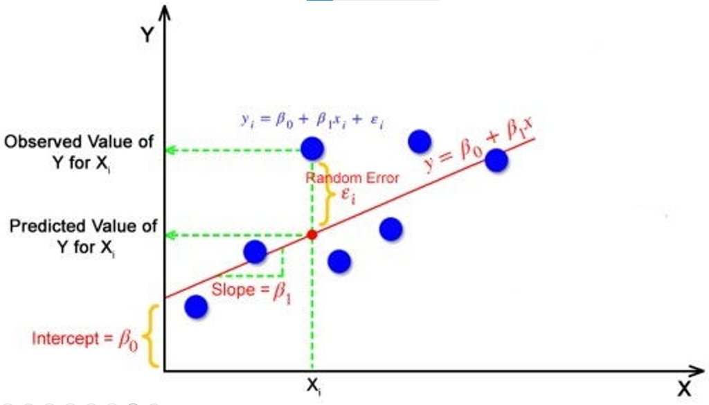

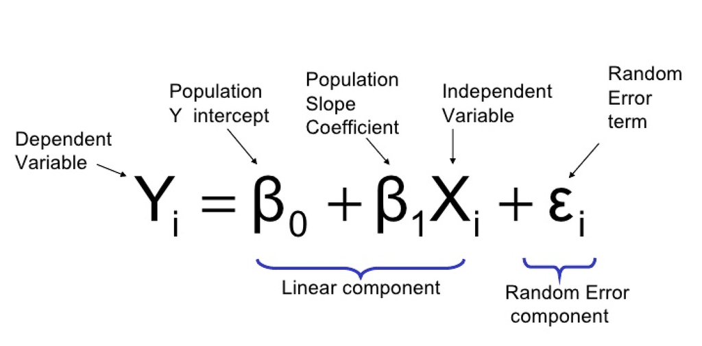

### Finding the Best Fit Line

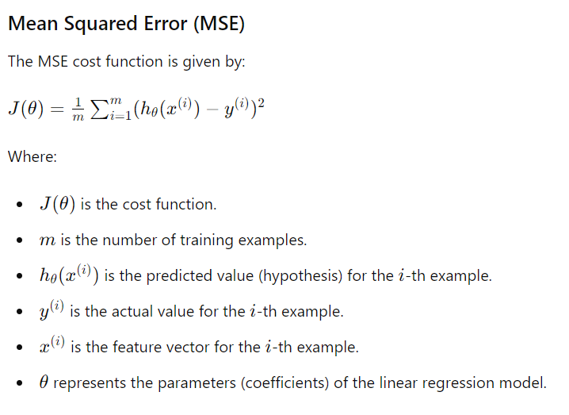

The goal of the linear regression algorithm is to get the best values for B0 and B1 to find the best fit line.

The best fit line is the line that has the least error which means the error between predicted values and actual values should be minimum.

In regression, the difference between the observed value of the dependent variable(Yi) and the predicted value(predicted) is called the residuals.

*Where Y Predicted = B0 + B1 * Xi*

In simple terms, the best fit line is a line that fits the given scatter plot in the best way. Mathematically, the best fit line is obtained by minimizing the Residual Sum of Squares(RSS).

### Finding the Best Fit Line

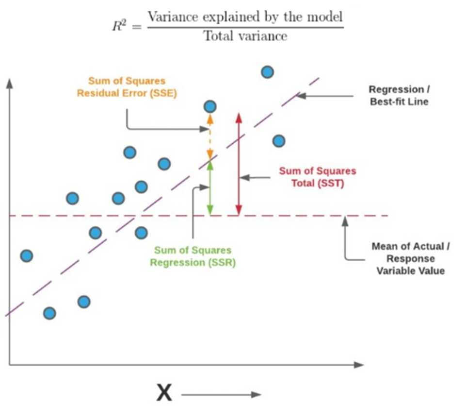

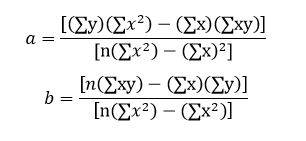

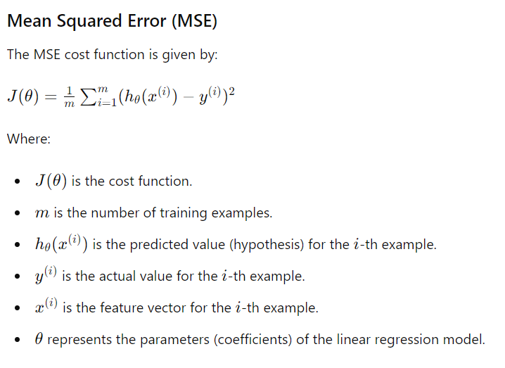

### Evaluating the Model

R-squared (The Goodness of Fit): Proportion of variance in the dependent variable that is predictable from the independent variables.

Adjusted R-squared: Modified version of R-squared adjusted for the number of predictors.

F-Statistic: Tests whether at least one predictor variable has a non-zero coefficient.

t-Tests on Coefficients: Each beta coefficient has an associated t-test to determine if the variable is statistically significant.

### Linear Regression Example

Scenario: A real estate company wants to predict the selling price of houses based on various features.

Variables:

Price: Selling price of the house (in thousands of dollars).

Size: Size of the house in square feet.

Bedrooms: Number of bedrooms.

Age: Age of the house in years.

Location: Categorical variable indicating the neighborhood quality (1 = Low, 2 = Medium, 3 = High).

### Simple Linear Regression

| **House ID** | **Price** | **Size** |
| --- | --- | --- |
| 1 | 250 | 1500 |
| 2 | 315 | 1800 |
| 3 | 270 | 1650 |
| 4 | 230 | 1400 |
| 5 | 450 | 2000 |
| 6 | 190 | 1300 |
| 7 | 350 | 1850 |
| 8 | 300 | 1600 |
| 9 | 280 | 1500 |
| 10 | 310 | 1700 |

#### Try this in R

- **Purpose:** Fit the house-price regression.
- **Before running:** `read.csv()` loads the ten houses; price is in thousands of dollars and size in square feet. `lm(price~size,data=houses)` fits a line with an intercept; `~` places the response on the left and predictor on the right. `summary()` displays coefficients and fit.

```r
# read.csv() imports the ten houses printed in the source; price is in thousands of dollars and size in square feet.
# lm(price~size) fits least squares with an intercept; summary() reports coefficients, R-squared, and inference.
# Open the course folder in Positron; paths start in that folder.
houses <- read.csv("data/inferential-statistics/houses.csv")
simple <- lm(price~size,data=houses)
summary(simple)
```

```
Call:
lm(formula = price ~ size, data = houses)

Residuals:
    Min      1Q  Median      3Q     Max
-32.891 -11.816  -2.266  13.125  39.297

Coefficients:
              Estimate Std. Error t value Pr(>|t|)
(Intercept) -217.42188   62.32294  -3.489  0.00821 **
size           0.31406    0.03794   8.278 3.41e-05 ***
---
Signif. codes:  0 '***' 0.001 '**' 0.01 '*' 0.05 '.' 0.1 ' ' 1

Residual standard error: 24.47 on 8 degrees of freedom
Multiple R-squared:  0.8955,    Adjusted R-squared:  0.8824
F-statistic: 68.53 on 1 and 8 DF,  p-value: 3.412e-05
```

**Read the result:** The slope is change in fitted price per square foot, in thousands of dollars. Read uncertainty and units; a fitted association is not evidence of causation.

### Regression Statistics

- **Multiple R (0.946288)**:

This is the **correlation coefficient**, showing the strength and direction of the linear relationship between the independent variable (Size) and the dependent variable (Price).

Value close to 1 or -1 indicates a strong linear relationship.

- **R Square (0.895461)**:

The **coefficient of determination**, indicating how much of the variation in the dependent variable (Price) is explained by the independent variable (Size).

In this case, ~89.55% of the variance in price is explained by size.

- **Adjusted R Square (0.882394)**:

Adjusted for the number of predictors in the model.

Useful when comparing models with different numbers of predictors; penalizes for adding non-significant predictors.

- **Standard Error (24.46997)**:

The **standard deviation of the residuals**. Smaller values indicate better model fit, as residuals are closer to zero.

- **Observations (10)**:

The number of data points used in the regression analysis.

### ANOVA (Analysis of Variance):

The ANOVA table tests whether the regression model as a whole is statistically significant.

- **df** **(Degrees of Freedom)**:

Regression: Number of predictors (1) + Intercept (0) = 1.

Residual: Total observations (10) - Number of predictors (1) - 1 = 8.

- **SS (Sum of Squares)**:

**Regression SS (41032.27)**: Variation in the dependent variable explained by the model.

**Residual SS (4790.234)**: Variation not explained by the model (errors).

**Total SS (45822.5)**: Total variation in the dependent variable.

- **MS (Mean Square)**:

**Regression MS (41032.27)**: Regression SS divided by its df: 41032.27 ÷ 1

**Residual MS (598.7793)**: Residual SS divided by its df: 4790.234 ÷ 8

- **F (68.52653)**:

The **F-statistic**, which tests whether the regression model explains a significant proportion of the variation in the dependent variable.

Larger values indicate the model is a good fit.

- **Significance F (3.41185E-05)**:

The **p-value** for the F-test. A small value (e.g., <0.05) indicates the model is statistically significant.

#### Try this in R

- **Purpose:** Display the regression analysis-of-variance table.
- **Before running:** `anova(simple)` uses the fitted model from the preceding R example. It partitions response variation into regression and residual parts and reports the F test of zero slope.

```r
# anova() partitions the fitted model's variability into regression and residual components.
# The F test assumes the source's independent, constant-variance normal-error linear model.
anova(simple)
```

```
Analysis of Variance Table

Response: price
          Df Sum Sq Mean Sq F value    Pr(>F)
size       1  41032   41032  68.526 3.412e-05 ***
Residuals  8   4790     599
---
Signif. codes:  0 '***' 0.001 '**' 0.01 '*' 0.05 '.' 0.1 ' ' 1
```

**Read the result:** The F test is conditional on the linear-model assumptions. It does not establish that the model is useful for every prediction task.

### Conclusion

- The model is statistically significant (Significance F < 0.05), and **Size** has a significant positive effect on Price (p-value for Size is very small).
- The model explains ~89.55% of the variation in Price (R² = 0.895461), which is strong.
- The residuals have a standard error of 24.47, indicating the average prediction error.

**What Does Standard Error Mean in Regression?**

In regression, the **standard error (SE)** reported in the output refers to the **standard deviation of the residuals**, also known as the **residual standard error (RSE)** or simply the "standard error of the regression." It measures how far the observed data points (dependent variable values) are from the predicted values, on average.

It tells you how much variability (or error) remains unexplained by your model.

### Multiple Linear Regression

Overall model p-value (significance), small value  good model

Smaller P-Value  Best Predictor

| **House ID** | **Price** | **Size** | **Bedrooms** | **Age** | **Location** |
| --- | --- | --- | --- | --- | --- |
| 1 | 250 | 1500 | 3 | 10 | 2 |
| 2 | 315 | 1800 | 4 | 15 | 3 |
| 3 | 270 | 1650 | 3 | 5 | 3 |
| 4 | 230 | 1400 | 2 | 20 | 2 |
| 5 | 450 | 2000 | 4 | 2 | 3 |
| 6 | 190 | 1300 | 3 | 30 | 1 |
| 7 | 350 | 1850 | 4 | 8 | 3 |
| 8 | 300 | 1600 | 3 | 12 | 2 |
| 9 | 280 | 1500 | 3 | 10 | 2 |
| 10 | 310 | 1700 | 3 | 6 | 3 |

Overall Model Accuracy

#### Try this in R

- **Purpose:** Fit the multiple-regression specification.
- **Before running:** `factor(location)` makes the location codes categories. In `lm()`, `+` adds predictors; size, bedrooms, age and location are modelled together. `summary()` displays their partial slopes and uncertainty.

```r
# factor(location) treats the source location codes 1,2,3 as categories rather than equal-spaced numerical scores.
# lm() adds size, bedrooms, age, and location effects; ten rows provide very limited residual degrees of freedom.
houses$location <- factor(houses$location)
multiple <- lm(price~size+bedrooms+age+location,data=houses)
summary(multiple)
```

```
Call:
lm(formula = price ~ size + bedrooms + age + location, data = houses)

Residuals:
         1          2          3          4          5          6          7
-1.001e+01  5.566e-01 -8.494e+00  3.957e+00  5.331e+00 -3.997e-15 -1.931e+00
         8          9         10
-1.394e+01  1.999e+01  4.538e+00

Coefficients:
              Estimate Std. Error t value Pr(>|t|)
(Intercept) -398.66093   94.74177  -4.208  0.01361 *
size           0.56566    0.08484   6.667  0.00263 **
bedrooms     -35.75155   17.95830  -1.991  0.11734
age           -1.31487    1.21789  -1.080  0.34106
location2    -69.42323   29.56473  -2.348  0.07867 .
location3   -142.35951   39.27624  -3.625  0.02227 *
---
Signif. codes:  0 '***' 0.001 '**' 0.01 '*' 0.05 '.' 0.1 ' ' 1

Residual standard error: 14.45 on 4 degrees of freedom
Multiple R-squared:  0.9818,    Adjusted R-squared:  0.959
F-statistic: 43.09 on 5 and 4 DF,  p-value: 0.001427
```

**Read the result:** Interpret a slope while holding the other model predictors fixed. Ten houses leave very few residual degrees of freedom; this is not evidence of a reliable general prediction system.

### Assumptions of Linear Regression

1. Linearity

The relationship between the independent variables (predictors) and the dependent variable (response) should be linear.

This means that the change in the dependent variable is proportional to the change in the independent variable.

**Example**: If you are predicting house prices (dependent variable) based on the size of the house (independent variable), a linear relationship implies that each additional square foot of the house size increases the price by a constant amount.

### Assumptions of Linear Regression

**How to Test Linearity**: Plot the residuals vs. predicted using a scatter plot, look for a random distribution (no patterns).

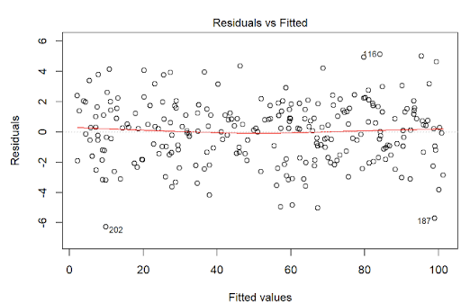

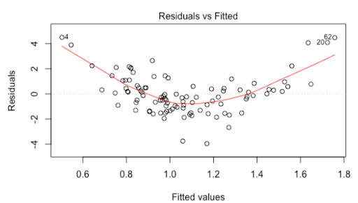

To check if the relationship between the independent variable (Size) and the dependent variable (Price) is linear, we look for patterns in the residuals, a random scatter indicates a linear relationship while curves or trends suggest a non-linear relationship.

#### Try this in R

- **Purpose:** Inspect residual pattern and spread in the house-price model.
- **Before running:** `fitted(simple)` returns predicted prices and `resid(simple)` returns observed minus predicted prices. `plot(x,y)` draws them; `pch` sets point shape, `col` colour and `xlab`/`ylab` the axis labels. `abline(h=0,lty=2)` adds a dashed zero reference.

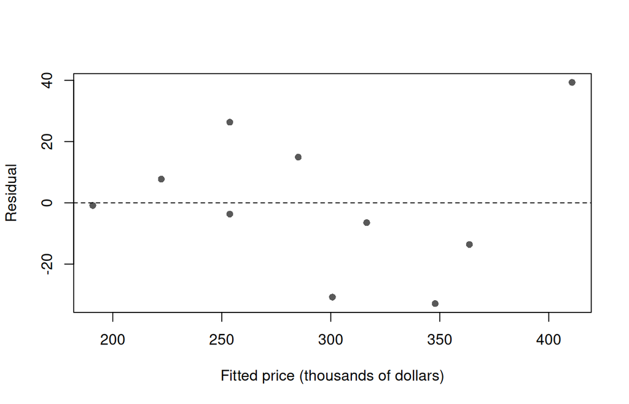

```r
# fitted() returns predicted prices and resid() returns observed minus fitted prices in thousands of dollars.
# abline(h=0) adds a horizontal reference: patterns may reveal model problems, not prove an assumption.
plot(fitted(simple),resid(simple),pch=16,col="#595959",xlab="Fitted price (thousands of dollars)",ylab="Residual")
abline(h=0,lty=2)
```

**Read the result:** Look for curvature, changing spread or unusual points. A diagnostic can reveal problems but cannot prove model assumptions.

### Assumptions of Linear Regression

2. Independence

Observations should be independent of each other. This means that the residuals (errors) should not be correlated across observations. This assumption is important for the validity of standard statistical tests.

Example: In a study measuring the effect of a new drug on blood pressure, each patient's measurement should be independent. If measurements from the same patient at different times are used, they are not independent.

**How to Test**: Use the Durbin-Watson test to check for autocorrelation in residuals, particularly for time-series data. This test calculates a test statistic (range 0-4). A value around 2 indicates no autocorrelation, values <2 suggest positive autocorrelation, and >2 indicate negative autocorrelation.

### Assumptions of Linear Regression

3. Homoscedasticity

The variance of the error terms (residuals) should be constant across all levels of the independent variables.

If this assumption is violated, it indicates heteroscedasticity, meaning the spread of residuals varies at different levels of the independent variables.

**Example:** When plotting residuals against fitted values in a regression analysis of apartment prices against apartment size, the spread of residuals should be roughly constant. If residuals spread out more as apartment size increases, this indicates heteroscedasticity.

### Assumptions of Linear Regression

**How to Test Homoscedasticity** : Plot residuals vs. predicted values. The spread of residuals variance should be consistent (no funnel-shaped patterns).

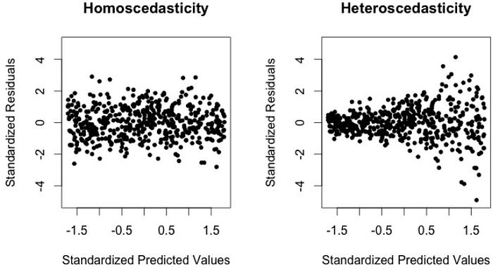

**Good Residual Spead**

**Good Linear Relation**

**Not a Good Residual Spead**

**Not a Good Linear Relation**

**Funnel shape note good**

**الشكل مثل القمع يبين بأن العلاقة الخطية غير مناسبة**

**التوزيع العشوائي للنقاط حول الصفر على طول المدى هو التوزيع الأفضل الذي يبين أن الموديل الخطي مناسب**

### Assumptions of Linear Regression

4. Normal Distribution of Errors

The error terms should be normally distributed. This assumption is especially important for small sample sizes because it affects the validity of confidence intervals and hypothesis tests.

Example: After fitting a regression model predicting apartment price based on apartment size, plotting a histogram or a Q-Q plot of the residuals should show that they follow a normal distribution.

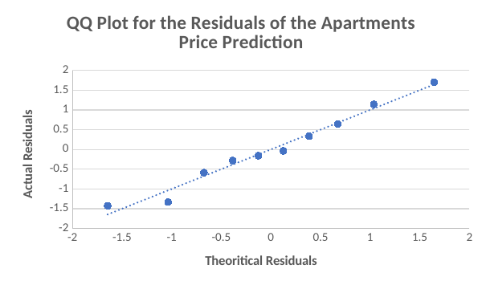

| Residuals | Standard Residuals | Rank | Percentiles | Theoritical Residuals |
| --- | --- | --- | --- | --- |
| -32.890625 | -1.425656831 | 1 | 0.05 | -1.644853627 |
| -30.78125 | -1.334225158 | 2 | 0.15 | -1.036433389 |
| -13.59375 | -0.589226339 | 3 | 0.25 | -0.67448975 |
| -6.484375 | -0.281067736 | 4 | 0.35 | -0.385320466 |
| -3.671875 | -0.159158839 | 5 | 0.45 | -0.125661347 |
| -0.859375 | -0.037249941 | 6 | 0.55 | 0.125661347 |
| 7.734375 | 0.335249469 | 7 | 0.65 | 0.385320466 |
| 14.921875 | 0.646794429 | 8 | 0.75 | 0.67448975 |
| 26.328125 | 1.141202737 | 9 | 0.85 | 1.036433389 |
| 39.296875 | 1.703338209 | 10 | 0.95 | 1.644853627 |

#### Try this in R

- **Purpose:** Compare the model’s residuals with a normal shape.
- **Before running:** `qqnorm()` plots ordered residuals against theoretical normal quantiles; `pch` and `col` control the points. `qqline()` adds a reference line.

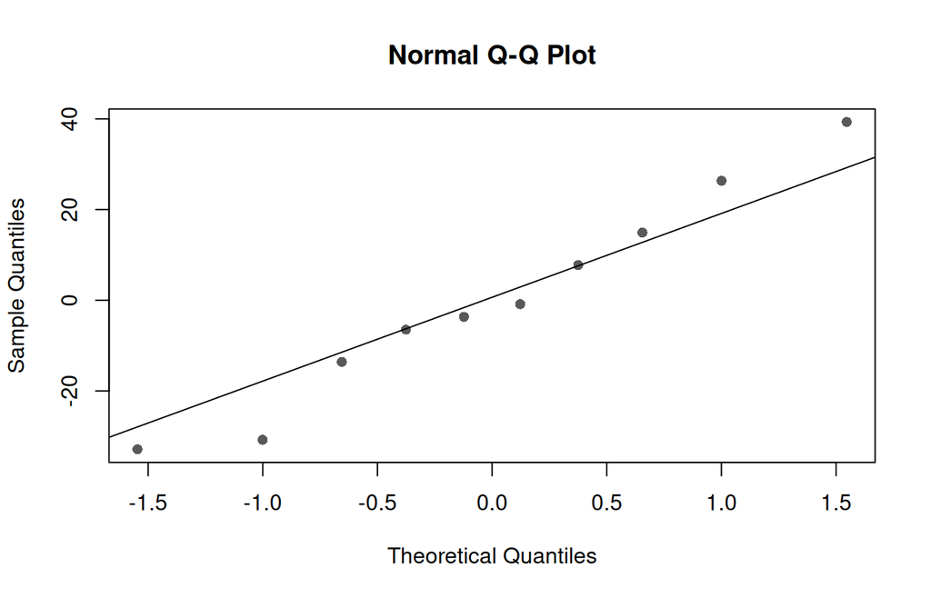

```r
# qqnorm() compares residual quantiles with a normal distribution; qqline() adds a reference line.
# This plot examines the error-normality assumption; it does not require normally distributed predictors.
qqnorm(resid(simple),pch=16,col="#595959")
qqline(resid(simple))
```

**Read the result:** Assess departures from the line, especially in the tails. Normality of errors is distinct from normality of the predictors.

### Assumptions of Linear Regression

5. No Multicollinearity

Independent variables should not be too highly correlated with each other. High correlation between predictors (multicollinearity) can inflate the variances of the coefficient estimates and make the model unstable.

Example: In a regression model predicting salary based on education level and years of experience, if education level and years of experience are highly correlated, it could cause multicollinearity issues. Checking the Variance Inflation Factor (VIF) can help detect this.

**How to Test**: Calculate Variance Inflation Factor (VIF). VIF values above 10 (or sometimes 5) indicate high multicollinearity. A VIF >10 (or sometimes >5) indicates problematic multicollinearity.